# Seattle's Perfect Summer: Fact or Fiction?

Stephanie Roark  
12-12-2018

### Seattle's Perfect Summer Day

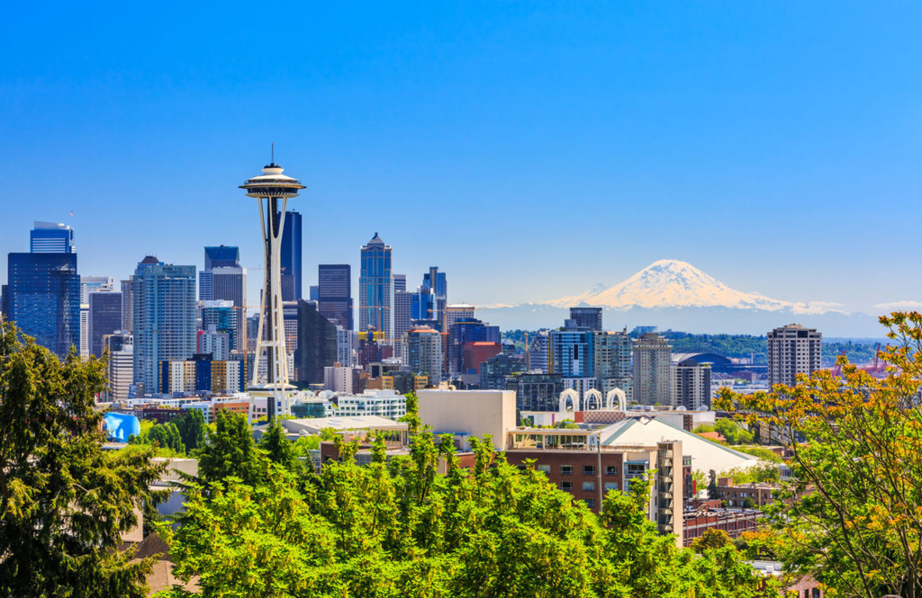

### Seattle's Perfect Summer: Fact or Fiction?

Fact!

- The number of perfect weather days in Seattle is increasing on average every year!
- Perfect weather days tend to occur more in the summer time when the rain dries up
- Air quality issues of summer wildfires have not greatly impacted the number of perfect days
- Weekends do not tend to be more rainy than weekdays in the summer time

### Seattle's Perfect Summer: Fact or Fiction?

- NOAA's weather dataset measured at Seattle-Tacoma Airport (SeaTac) spanning from 1948 to present, containing 50 variables including both max and min temperature and precipitation: Seattle Daily
- EPA's pre-generated air quality dataset with the air quality index by day for every county in the US and spanning from 01.01.1980 to 11.27.2018: AQI
- Seattle events data: Seattle Special Events Data

### Temperature and Air Quality from 2012 to 2017

Consistent Temperature and Air Quailty Ranges

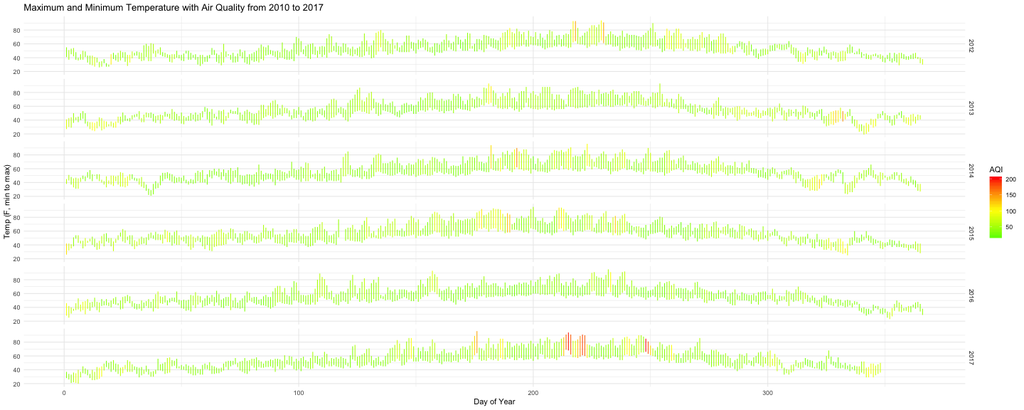

### Rain Rain Rain

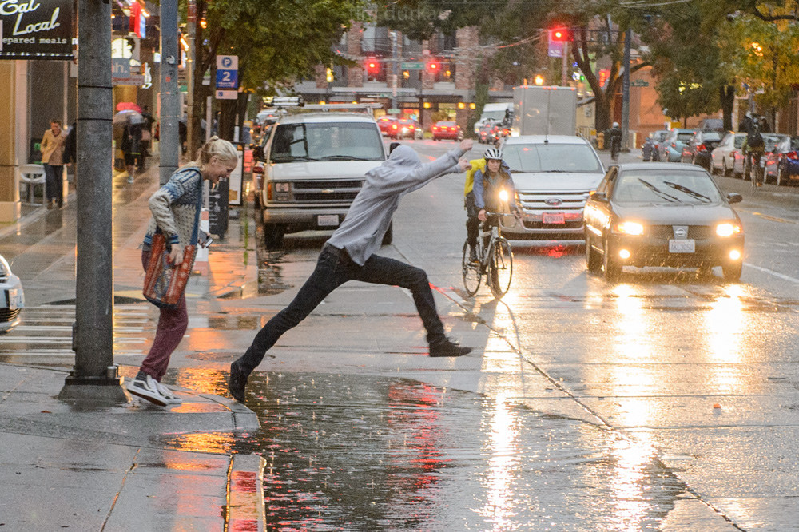

### Precipitation

We can see gaps in precipitation

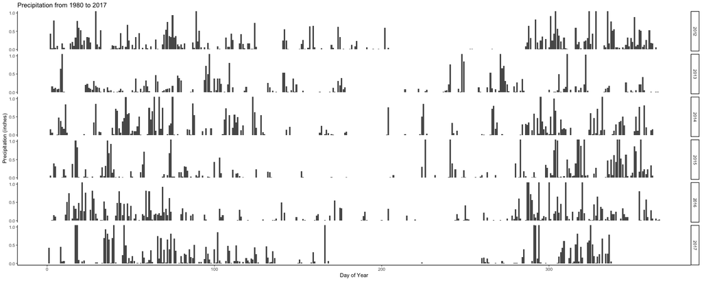

### What is Perfect?

working definition of perfect weather

- Temperature Range between 55 and 85 degrees F
- Air Quality index below 100 which is the max range for moderate air quality before the air quality becomes unhealthy for sensitive groups
- Precipitation less than or equal to 0.05 inches per day

### Seattle's Pefect Days

The Perfect Weather days tend to happen in middle of year

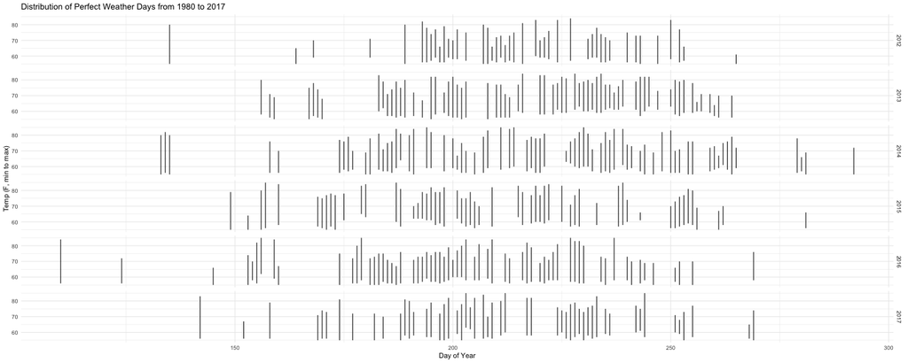

### Predicting Perfect Weather Days

The number of perfect days on average is increasing by 0.79 days per year

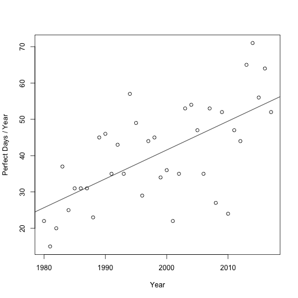

```
[1] 428
```

```
[1] 0.2790091
```

### Weekends and Events

- 428 perfect weather days fall on weekends, which is 27.9% of the perfect weather days
- 22 events dates coincide with perfect weather dates and that these dates occur between June 1 and September 30

### Conclusion - Follow up analysis

Follow up analysis could compare other Pacific Northwest cities and/or cities around the US to see if Seattle's summer is really special.